## import the library we need.

```python
import numpy as np
import pandas as pd
import matplotlib.pyplot as plt
import seaborn as sns
from sklearn.cluster import KMeans
from sklearn.decomposition import PCA
from scipy.fft import fft, fftfreq, fftshift
from sklearn.preprocessing import StandardScaler
```

# 1. From the NASDAQ csv file,

## (a) create a Pandas dataframe (name the dataframe “com12”) containing all data in the csv file corresponding to the following 12 companies:

- AAPL
- ADBE
- AMD
- AMZN
- ASML
- FB
- GOOG
- INTC
- MSFT
- NVDA
- PYPL
- TSLA

```python
companies12 = ['AAPL', 'ADBE', 'AMD', 'AMZN', 'ASML', 'FB', 'GOOG', 'INTC', 'MSFT', 'NVDA', 'PYPL', 'TSLA']
```

```python
# read csv
com12 = pd.read_csv('NASDAQ_100_Data_From_2010.csv', delimiter='\t')
com12 = com12[com12['Name'].isin(companies12)]
print('com12:')
com12
```

```
com12:
```

|  | Date | Open | High | Low | Close | Adj Close | Volume | Name |
| --- | --- | --- | --- | --- | --- | --- | --- | --- |
| 0 | 2010-01-04 | 7.622500 | 7.660714 | 7.585000 | 7.643214 | 6.562591 | 493729600 | AAPL |
| 1 | 2010-01-05 | 7.664286 | 7.699643 | 7.616071 | 7.656429 | 6.573935 | 601904800 | AAPL |
| 2 | 2010-01-06 | 7.656429 | 7.686786 | 7.526786 | 7.534643 | 6.469369 | 552160000 | AAPL |
| 3 | 2010-01-07 | 7.562500 | 7.571429 | 7.466071 | 7.520714 | 6.457407 | 477131200 | AAPL |
| 4 | 2010-01-08 | 7.510714 | 7.571429 | 7.466429 | 7.570714 | 6.500339 | 447610800 | AAPL |
| ... | ... | ... | ... | ... | ... | ... | ... | ... |
| 248227 | 2021-09-03 | 732.250000 | 734.000000 | 724.200012 | 733.570007 | 733.570007 | 15246100 | TSLA |
| 248228 | 2021-09-07 | 740.000000 | 760.200012 | 739.260010 | 752.919983 | 752.919983 | 20039800 | TSLA |
| 248229 | 2021-09-08 | 761.580017 | 764.450012 | 740.770020 | 753.869995 | 753.869995 | 18793000 | TSLA |
| 248230 | 2021-09-09 | 753.409973 | 762.099976 | 751.630005 | 754.859985 | 754.859985 | 14077700 | TSLA |
| 248231 | 2021-09-10 | 759.599976 | 762.609985 | 734.520020 | 736.270020 | 736.270020 | 15114300 | TSLA |

33211 rows × 8 columns

## (b) From com12, and with reference to the Dow Jones Industrial Average (DJIA) data in “Dow Jones Industrial Average Historical Data.csv”, plot the correlation of the “close” stock prices of each of the 12 companies with the *next day* “open” price of DJIA.

```python
com12_close = com12.groupby(['Date', 'Name'])['Close'].mean().unstack().fillna(method='bfill').reset_index()
com12_close_sample = com12_close[:-428]
com12_close_sample.drop(com12_close_sample.index[284], inplace = True)
com12_close_sample.reset_index(inplace=True, drop=True)
```

```python
DJIA = pd.read_csv('Dow Jones Industrial Average Historical Data.csv').iloc[::-1]
DJIA = DJIA.iloc[252:]
DJIA.reset_index(inplace=True, drop=True)
DJIA_open = pd.to_numeric(DJIA['Open'].str.replace(',', '')) / 10
```

```python
def changeMonthFormat(month):
    if month == 'Jan':
        return '01'
    elif month == 'Feb':
        return '02'
    elif month == 'Mar':
        return '03'
    elif month == 'Apr':
        return '04'
    elif month == 'May':
        return '05'
    elif month == 'Jun':
        return '06'
    elif month == 'Jul':
        return '07'
    elif month == 'Aug':
        return '08'
    elif month == 'Sep':
        return '09'
    elif month == 'Oct':
        return '10'
    elif month == 'Nov':
        return '11'
    elif month == 'Dec':
        return '12'

def changeDateFormat(date):
    for idx in range(len(date)):
        d = date[idx]
        date[idx] = str(d[-4:]) + '-' + changeMonthFormat(d[0:3]) + '-' + str(d[4:6])
```

```python
changeDateFormat(DJIA['Date'])
```

[figure not shown]

```python
com12_close_DJIA_open = com12_close_sample
com12_close_DJIA_open['DJIA open (* 10)'] = DJIA_open
com12_close_DJIA_open.plot()
```

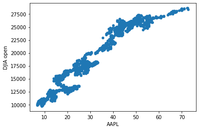

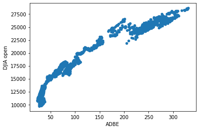

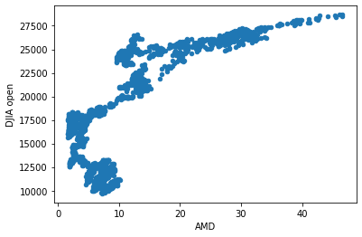

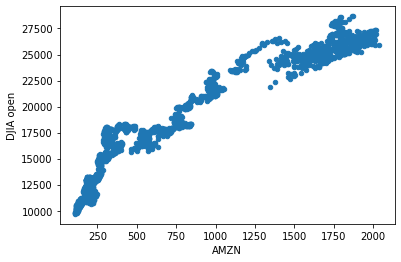

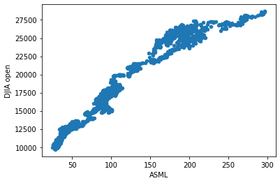

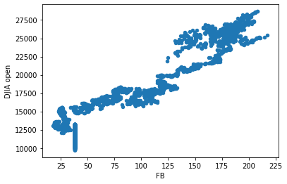

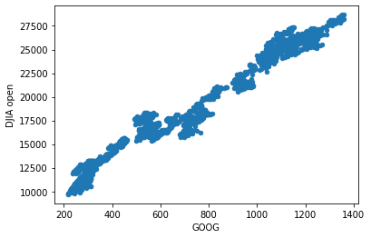

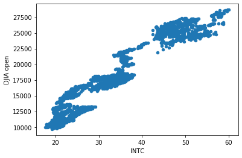

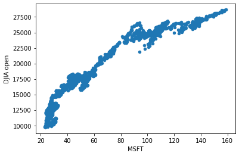

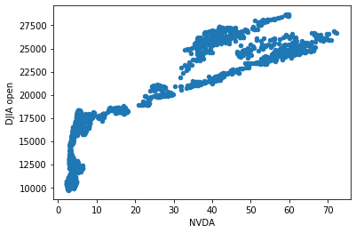

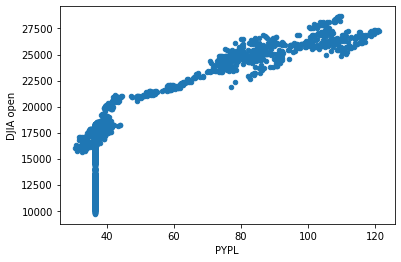

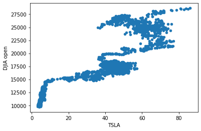

```python
com12_close_DJIA_open['DJIA open'] = pd.to_numeric(DJIA['Open'].str.replace(',', ''))
for company in companies12:
    com12_close_DJIA_open.plot.scatter(x=company, y='DJIA open')
```

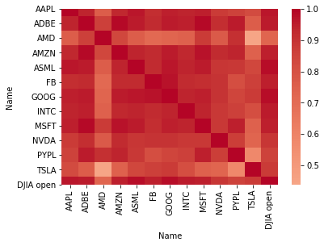

```python
# plt.figure(figsize=(10, 10))
com12_close_DJIA_open = com12_close_DJIA_open.drop('DJIA open (* 10)', axis=1)
sns.heatmap(com12_close_DJIA_open.corr(), annot=False, center=0.0, cmap='coolwarm'); # cmap="YlGnBu",
plt.show()
```

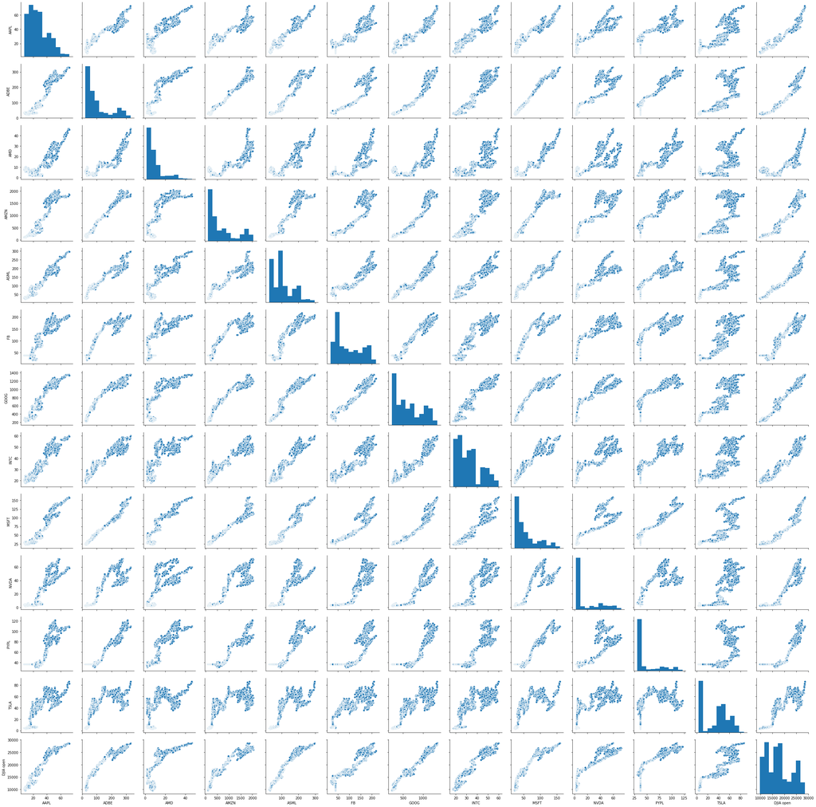

```python
sns.pairplot(com12_close_DJIA_open)
plt.show()
```

**Reference:**

- fill NaN with next value: https://stackoverflow.com/questions/27905295/how-to-replace-nans-by-preceding-or-next-values-in-pandas-dataframe
- select columns from groupby object in pandas: https://stackoverflow.com/questions/19202093/how-to-select-columns-from-groupby-object-in-pandas

## (c) From com12, perform the following:

### i. create another Pandas dataframe of “close” stock prices with date resolution changed from day to month i.e. reduce all prices of the same month with one record containing the average “close” price of the month. Name this dataframe “com12month”.

```python
com12month = com12_close
com12month['year'] = pd.DatetimeIndex(com12month['Date']).year
com12month['month'] = pd.DatetimeIndex(com12month['Date']).month
com12month = com12month.groupby(['year', 'month']).mean().T
```

```python
print('com12month:')
com12month
```

```
com12month:
```

| year month Name | 2010 1 | 2010 2 | 2010 3 | 2010 4 | 2010 5 | 2010 6 | 2010 7 | 2010 8 | 2010 9 | 2010 10 | ... | 2020 12 | 2021 1 | 2021 2 | 2021 3 | 2021 4 | 2021 5 | 2021 6 | 2021 7 | 2021 8 | 2021 9 |
| --- | --- | --- | --- | --- | --- | --- | --- | --- | --- | --- | --- | --- | --- | --- | --- | --- | --- | --- | --- | --- | --- |
| AAPL | 7.418402 | 7.099850 | 7.978960 | 8.969592 | 8.980768 | 9.326624 | 9.105357 | 8.975828 | 9.780391 | 10.747653 | ... | 127.290455 | 133.036842 | 131.531579 | 121.871304 | 131.812858 | 126.784000 | 129.958636 | 145.139524 | 148.177727 | 153.614286 |
| ADBE | 35.577895 | 32.990527 | 35.283913 | 35.118572 | 32.895000 | 31.250909 | 27.853810 | 28.328637 | 29.798095 | 27.512381 | ... | 491.362274 | 470.753681 | 483.538422 | 451.366088 | 508.677147 | 489.344499 | 545.707729 | 609.197144 | 639.683638 | 663.192862 |
| AMD | 8.794737 | 7.792632 | 8.969565 | 9.624286 | 8.651500 | 8.247727 | 7.533333 | 6.614545 | 6.299524 | 7.098095 | ... | 93.196818 | 91.678421 | 88.679474 | 79.366522 | 81.844286 | 76.976000 | 83.331363 | 92.046667 | 108.794091 | 107.968570 |
| AMZN | 127.423158 | 118.021053 | 130.897391 | 141.070000 | 127.606000 | 121.667272 | 117.519048 | 126.372727 | 147.664287 | 160.741427 | ... | 3197.750000 | 3200.048391 | 3263.868383 | 3068.272620 | 3352.174270 | 3246.260010 | 3367.725431 | 3616.006185 | 3312.917725 | 3486.895717 |
| ASML | 33.117895 | 31.525789 | 34.241305 | 35.086667 | 29.823000 | 29.283636 | 30.845238 | 29.036818 | 28.075714 | 31.639524 | ... | 468.888181 | 530.291049 | 573.104216 | 559.452608 | 644.018093 | 644.137503 | 688.425462 | 713.769520 | 795.797727 | 856.241429 |
| FB | 38.230000 | 38.230000 | 38.230000 | 38.230000 | 38.230000 | 38.230000 | 38.230000 | 38.230000 | 38.230000 | 38.230000 | ... | 276.530907 | 264.609474 | 266.337894 | 275.506957 | 307.753810 | 317.335997 | 336.425909 | 353.377145 | 363.016821 | 378.575714 |
| GOOG | 288.220202 | 266.447866 | 279.467487 | 277.491086 | 247.737919 | 241.331340 | 235.600009 | 238.761651 | 246.344025 | 286.893935 | ... | 1772.278182 | 1808.383693 | 2068.356824 | 2059.844785 | 2289.842367 | 2352.595496 | 2501.394098 | 2646.785703 | 2786.406827 | 2891.637102 |
| INTC | 20.607368 | 20.159474 | 21.623044 | 23.255714 | 21.763500 | 20.780000 | 20.861905 | 19.397273 | 18.729048 | 19.573333 | ... | 49.316364 | 55.020000 | 60.197368 | 62.879131 | 63.085715 | 56.151000 | 56.813636 | 55.245238 | 53.512727 | 53.624286 |
| MSFT | 30.146842 | 28.356316 | 29.258696 | 30.522857 | 28.117000 | 25.420455 | 25.074286 | 24.706818 | 24.594762 | 25.181905 | ... | 217.963181 | 221.975261 | 240.066842 | 233.674349 | 255.579998 | 247.395498 | 259.018181 | 281.502385 | 294.314090 | 299.638567 |
| NVDA | 4.357632 | 4.159605 | 4.330000 | 4.234167 | 3.401750 | 2.902955 | 2.586071 | 2.369091 | 2.703452 | 2.840357 | ... | 132.247387 | 132.878553 | 142.772764 | 128.761088 | 150.102975 | 146.881999 | 182.186704 | 196.463452 | 207.121819 | 224.765714 |
| PYPL | 36.709999 | 36.709999 | 36.709999 | 36.709999 | 36.709999 | 36.709999 | 36.709999 | 36.709999 | 36.709999 | 36.709999 | ... | 226.035907 | 239.788946 | 274.426319 | 244.925870 | 264.831428 | 250.618501 | 275.742730 | 296.913811 | 276.529545 | 287.300005 |
| TSLA | 4.778000 | 4.778000 | 4.778000 | 4.778000 | 4.778000 | 4.777454 | 3.911619 | 3.902182 | 4.148095 | 4.142667 | ... | 638.818640 | 828.776839 | 794.269470 | 656.802607 | 709.618094 | 616.753000 | 626.919550 | 659.134760 | 705.243172 | 742.567147 |

12 rows × 141 columns

**Reference:**

- Extract month and year from column in Pandas, create new column: https://www.interviewqs.com/ddi-code-snippets/extract-month-year-pandas

### ii. Using KMEANS clustering technique, cluster the 12 com12month data vectors corresponding to the 12 companies into clusters based on the company’s monthly average price. You may decide on a reasonable/meaningful number of clusters.

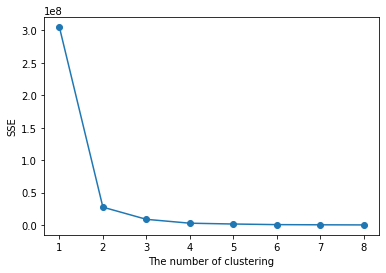

```python
com12month_np = com12month.values
SSE = []
for k in range(1, 9):
    estimator = KMeans(n_clusters = k)
    estimator.fit(com12month_np)
    SSE.append(estimator.inertia_)
X = range(1, 9)
plt.xlabel('The number of clustering')
plt.ylabel('SSE') # within-cluster variation
plt.plot(X, SSE, 'o-')
plt.show()
```

Because the SSE when k is 3 is already less than one-seventh when k is 1, and the amount of SSE reduced is less after k become larger than 3, deciding to be splited to 3 clusters.

```python
k = 3
kmeans_fit = KMeans(n_clusters = k).fit(com12month_np)
clusters = KMeans(n_clusters = k).fit_predict(com12month_np)
print('clusters: ', clusters)
```

```
clusters:  [0 0 0 2 0 0 1 0 0 0 0 0]
```

```python
for i in range(k):
    col = com12month.T.columns[np.where(clusters == i)]
    print(f'cluster {i+1}:', np.array(col))
    print(com12month.T[col].T)
    print()
```

```
cluster 1: ['AAPL' 'ADBE' 'AMD' 'ASML' 'FB' 'INTC' 'MSFT' 'NVDA' 'PYPL' 'TSLA']
year        2010                                                         \
month         1          2          3          4          5          6
Name
AAPL    7.418402   7.099850   7.978960   8.969592   8.980768   9.326624
ADBE   35.577895  32.990527  35.283913  35.118572  32.895000  31.250909
AMD     8.794737   7.792632   8.969565   9.624286   8.651500   8.247727
ASML   33.117895  31.525789  34.241305  35.086667  29.823000  29.283636
FB     38.230000  38.230000  38.230000  38.230000  38.230000  38.230000
INTC   20.607368  20.159474  21.623044  23.255714  21.763500  20.780000
MSFT   30.146842  28.356316  29.258696  30.522857  28.117000  25.420455
NVDA    4.357632   4.159605   4.330000   4.234167   3.401750   2.902955
PYPL   36.709999  36.709999  36.709999  36.709999  36.709999  36.709999
TSLA    4.778000   4.778000   4.778000   4.778000   4.778000   4.777454

year                                               ...        2020  \
month         7          8          9          10  ...          12
Name                                               ...
AAPL    9.105357   8.975828   9.780391  10.747653  ...  127.290455
ADBE   27.853810  28.328637  29.798095  27.512381  ...  491.362274
AMD     7.533333   6.614545   6.299524   7.098095  ...   93.196818
ASML   30.845238  29.036818  28.075714  31.639524  ...  468.888181
FB     38.230000  38.230000  38.230000  38.230000  ...  276.530907
INTC   20.861905  19.397273  18.729048  19.573333  ...   49.316364
MSFT   25.074286  24.706818  24.594762  25.181905  ...  217.963181
NVDA    2.586071   2.369091   2.703452   2.840357  ...  132.247387
PYPL   36.709999  36.709999  36.709999  36.709999  ...  226.035907
TSLA    3.911619   3.902182   4.148095   4.142667  ...  638.818640

year         2021                                                              \
month          1           2           3           4           5           6
Name
AAPL   133.036842  131.531579  121.871304  131.812858  126.784000  129.958636
ADBE   470.753681  483.538422  451.366088  508.677147  489.344499  545.707729
AMD     91.678421   88.679474   79.366522   81.844286   76.976000   83.331363
ASML   530.291049  573.104216  559.452608  644.018093  644.137503  688.425462
FB     264.609474  266.337894  275.506957  307.753810  317.335997  336.425909
INTC    55.020000   60.197368   62.879131   63.085715   56.151000   56.813636
MSFT   221.975261  240.066842  233.674349  255.579998  247.395498  259.018181
NVDA   132.878553  142.772764  128.761088  150.102975  146.881999  182.186704
```

[output cut: 49 more lines]

```
month          7           8           9           10  ...       12
Name                                                   ...
AMZN   117.519048  126.372727  147.664287  160.741427  ...  3197.75

year          2021                                                   \
month           1            2           3           4           5
Name
AMZN   3200.048391  3263.868383  3068.27262  3352.17427  3246.26001

year
month           6            7            8            9
Name
AMZN   3367.725431  3616.006185  3312.917725  3486.895717

[1 rows x 141 columns]
```

# 2. From the NASDAQ csv file,

## (a) Create a Pandas dataframe (name the dataframe “Nas2020”) containing the “close” stock prices in the csv file of all the records in the year 2020.

```python
Nas2020 = pd.read_csv('NASDAQ_100_Data_From_2010.csv', delimiter='\t')
Nas2020 = Nas2020.groupby(['Date', 'Name'])['Close'].mean().unstack().fillna(method='bfill').reset_index()
Nas2020['year'] = pd.DatetimeIndex(Nas2020['Date']).year
Nas2020 = Nas2020[Nas2020['year'] == 2020]
Nas2020 = Nas2020.drop(['year'], axis=1)
print('Nas2020:')
Nas2020
```

```
Nas2020:
```

| Name | Date | AAPL | ADBE | ADI | ADP | ADSK | AEP | ALGN | AMAT | AMD | ... | TSLA | TXN | VRSK | VRSN | VRTX | WBA | WDAY | XEL | XLNX | ZM |
| --- | --- | --- | --- | --- | --- | --- | --- | --- | --- | --- | --- | --- | --- | --- | --- | --- | --- | --- | --- | --- | --- |
| 2516 | 2020-01-02 | 75.087502 | 334.429993 | 120.430000 | 170.320007 | 187.830002 | 93.459999 | 283.679993 | 62.200001 | 49.099998 | ... | 86.052002 | 129.570007 | 151.119995 | 196.729996 | 219.449997 | 59.080002 | 167.460007 | 62.380001 | 101.650002 | 68.720001 |
| 2517 | 2020-01-03 | 74.357498 | 331.809998 | 118.309998 | 169.960007 | 184.949997 | 93.360001 | 280.440002 | 61.209999 | 48.599998 | ... | 88.601997 | 127.849998 | 152.589996 | 200.880005 | 217.979996 | 59.080002 | 168.440002 | 62.680000 | 99.309998 | 67.279999 |
| 2518 | 2020-01-06 | 74.949997 | 333.709991 | 116.919998 | 170.190002 | 187.119995 | 93.669998 | 285.880005 | 59.889999 | 48.389999 | ... | 90.307999 | 126.959999 | 152.940002 | 202.740005 | 224.029999 | 59.590000 | 169.490005 | 62.590000 | 97.239998 | 70.320000 |
| 2519 | 2020-01-07 | 74.597504 | 333.390015 | 119.580002 | 168.130005 | 187.500000 | 93.690002 | 283.059998 | 61.619999 | 48.250000 | ... | 93.811996 | 129.410004 | 154.220001 | 203.210007 | 223.789993 | 59.290001 | 172.949997 | 62.459999 | 99.459999 | 71.900002 |
| 2520 | 2020-01-08 | 75.797501 | 337.869995 | 120.660004 | 169.710007 | 189.949997 | 93.410004 | 286.000000 | 61.580002 | 47.830002 | ... | 98.428001 | 129.759995 | 155.639999 | 204.149994 | 231.089996 | 55.830002 | 178.710007 | 62.400002 | 99.180000 | 72.550003 |
| ... | ... | ... | ... | ... | ... | ... | ... | ... | ... | ... | ... | ... | ... | ... | ... | ... | ... | ... | ... | ... | ... |
| 2764 | 2020-12-24 | 131.970001 | 499.859985 | 144.470001 | 176.559998 | 301.390015 | 81.419998 | 528.030029 | 85.330002 | 91.809998 | ... | 661.770020 | 161.639999 | 201.229996 | 214.589996 | 234.460007 | 39.619999 | 248.759995 | 64.629997 | 141.990005 | 375.170013 |
| 2765 | 2020-12-28 | 136.690002 | 498.950012 | 144.679993 | 176.610001 | 299.649994 | 81.279999 | 520.859985 | 84.870003 | 91.599998 | ... | 663.690002 | 161.470001 | 207.979996 | 216.800003 | 232.470001 | 39.660000 | 241.919998 | 65.320000 | 141.520004 | 351.390015 |
| 2766 | 2020-12-29 | 134.869995 | 502.109985 | 143.660004 | 174.869995 | 298.109985 | 81.180000 | 520.450012 | 84.269997 | 90.620003 | ... | 665.989990 | 161.179993 | 205.669998 | 215.630005 | 233.490005 | 39.410000 | 237.720001 | 65.419998 | 139.899994 | 353.750000 |
| 2767 | 2020-12-30 | 133.720001 | 497.450012 | 146.179993 | 173.809998 | 299.410004 | 81.510002 | 524.320007 | 86.980003 | 92.290001 | ... | 694.780029 | 162.699997 | 205.779999 | 214.500000 | 232.679993 | 39.340000 | 236.929993 | 65.650002 | 142.100006 | 353.399994 |
| 2768 | 2020-12-31 | 132.690002 | 500.119995 | 147.729996 | 176.199997 | 305.339996 | 83.269997 | 534.380005 | 86.300003 | 91.709999 | ... | 705.669983 | 164.130005 | 207.589996 | 216.399994 | 236.339996 | 39.880001 | 239.610001 | 66.669998 | 141.770004 | 337.320007 |

253 rows × 103 columns

**Reference:**

- drop column: https://pandas.pydata.org/docs/reference/api/pandas.DataFrame.drop.html

## (b) Create another Pandas dataframe of “close” stock prices with date resolution changed from daily to weekly i.e. reduce all prices of the same week with one record containing the average “close” price of the week. Name this dataframe “Nas2020week”.

```python
Nas2020['week'] = pd.DatetimeIndex(Nas2020['Date']).week
Nas2020week = Nas2020.groupby(['week']).mean().T
print('Nas2020week:')
Nas2020week
```

```
Nas2020week:
```

| week Name | 1 | 2 | 3 | 4 | 5 | 6 | 7 | 8 | 9 | 10 | ... | 44 | 45 | 46 | 47 | 48 | 49 | 50 | 51 | 52 | 53 |
| --- | --- | --- | --- | --- | --- | --- | --- | --- | --- | --- | --- | --- | --- | --- | --- | --- | --- | --- | --- | --- | --- |
| AAPL | 74.722500 | 76.067000 | 78.747499 | 79.488127 | 79.218001 | 79.710001 | 80.909000 | 79.748123 | 71.289497 | 73.641000 | ... | 113.406000 | 114.375999 | 118.050000 | 118.739999 | 115.409998 | 122.008002 | 123.112000 | 126.565999 | 130.760002 | 134.492500 |
| ADBE | 333.119995 | 337.046002 | 345.664001 | 350.797501 | 352.214001 | 364.767993 | 373.616003 | 378.510002 | 347.837994 | 352.053998 | ... | 463.788000 | 475.458002 | 464.562000 | 463.540009 | 467.604996 | 481.832001 | 484.809998 | 491.454004 | 499.832504 | 499.657501 |
| ADI | 119.369999 | 119.278001 | 118.939999 | 119.539999 | 112.374001 | 113.439999 | 117.023999 | 122.442501 | 112.726001 | 109.359999 | ... | 118.980000 | 125.614000 | 135.946002 | 135.631998 | 136.915001 | 140.838000 | 142.810001 | 143.506000 | 143.639999 | 145.562496 |
| ADP | 170.140007 | 170.066003 | 173.629999 | 177.392502 | 174.295999 | 177.567999 | 179.344000 | 180.132500 | 164.063998 | 160.489999 | ... | 152.606003 | 164.292001 | 170.778000 | 174.252002 | 174.165001 | 173.401999 | 173.694000 | 176.213998 | 176.395000 | 175.372498 |
| ADSK | 186.389999 | 189.773999 | 192.039999 | 197.090000 | 198.296002 | 203.657999 | 207.094000 | 206.599998 | 188.659998 | 184.051999 | ... | 243.145999 | 250.054001 | 250.665997 | 253.098001 | 265.067497 | 278.338000 | 281.088000 | 294.076001 | 301.577499 | 300.627495 |
| ... | ... | ... | ... | ... | ... | ... | ... | ... | ... | ... | ... | ... | ... | ... | ... | ... | ... | ... | ... | ... | ... |
| WBA | 59.080002 | 56.722001 | 54.388000 | 53.157499 | 52.017999 | 52.600001 | 53.460000 | 51.812500 | 47.241999 | 48.441999 | ... | 35.072000 | 36.860000 | 41.409999 | 39.511999 | 38.642500 | 40.507999 | 41.874001 | 40.964000 | 39.857499 | 39.572500 |
| WDAY | 167.950005 | 176.148001 | 180.983997 | 183.792503 | 185.406000 | 190.264001 | 194.798001 | 192.845001 | 174.478000 | 166.865997 | ... | 212.389999 | 216.025998 | 219.545996 | 223.112000 | 214.745003 | 224.453995 | 222.491998 | 230.481998 | 249.387497 | 239.044998 |
| XEL | 62.530001 | 62.526000 | 64.342001 | 66.572500 | 67.902000 | 69.212001 | 69.425999 | 70.860001 | 66.945999 | 68.036000 | ... | 71.010001 | 72.904001 | 73.938002 | 71.299998 | 68.057501 | 67.502000 | 65.678000 | 65.951999 | 64.789999 | 65.764999 |
| XLNX | 100.480000 | 99.372000 | 100.328000 | 101.537502 | 91.070000 | 86.480002 | 89.692000 | 89.365000 | 82.927998 | 82.152000 | ... | 120.050002 | 126.321997 | 127.032001 | 131.228003 | 134.892502 | 146.152002 | 144.710001 | 150.788000 | 143.355003 | 141.322502 |
| ZM | 68.000000 | 72.096001 | 75.160001 | 74.935001 | 73.274002 | 87.268001 | 89.487999 | 101.842501 | 107.504001 | 117.340001 | ... | 504.675995 | 477.010004 | 406.962000 | 413.942004 | 443.289993 | 424.215997 | 400.035999 | 401.409998 | 394.255005 | 348.965004 |

102 rows × 53 columns

## (c) Perform Principal Component Analysis on the “close” stock price data vectors (one vector per company) in Nas2020week.

```python
def calculateCOV(matrix):
    return np.cov(matrix - matrix.mean(), rowvar=False)

def Decomposition(matrix):
    eigenvalue, eigenvector = np.linalg.eig(matrix)
    eigenvalue_descend_id = np.argsort(eigenvalue)[::-1]
    eigenvalue_descend = eigenvalue[eigenvalue_descend_id]
    eigenvector_descend = eigenvector.T[eigenvalue_descend_id]
    return eigenvalue_descend, eigenvector_descend

def calculate_coefficient_matrix(observations, eiganvectors, eigan_id):
    return np.matmul(np.array(observations), np.array(eiganvectors)[eigan_id].T)

def reconstruct_data(coefficient_matrix, eigenvectors):
    points = list()
    coef = np.array(coefficient_matrix)
    n_observations = np.shape(coefficient_matrix)[0]
    n_eigens = np.shape(coefficient_matrix)[1]
    print(n_observations, n_eigens)
    for observation in range(n_observations):
        point = np.zeros(len(eigenvectors))
        for eigen_id in range(n_eigens):
            point += coef[observation][eigen_id] * eigenvectors[eigen_id]
        points.append(point)
    return points

def PCA_model(matrix, newDim=2):
    covariance = calculateCOV(matrix)
    eigenvalues, eigenvectors = Decomposition(covariance)
    coef = calculate_coefficient_matrix(matrix, eigenvectors, [i for i in range(newDim)])
    points = reconstruct_data(coef, eigenvectors)
    return eigenvectors, points
```

```python
eigenvectors, points = PCA_model(Nas2020week, newDim=3)
```

```
102 3
```

## (d) Supposing you wish to reduce the dimension of the data vectors so that the machine learning input can take a reduced dimension feature vector. You wish to do so by projecting the data vectors onto the principal components and represent the data points using the projection coefficients. Explain how you would determine how many eigenvectors to use to reduce the data dimension.

```python
def calculate_explained_variance_ratio(matrix):
    cumulative_explained_variance_ratio = []
    covariance = calculateCOV(matrix)
    eigenvalues, eigenvectors = Decomposition(covariance)
    explained_variance_ratio = 0
    for eigenvalue in eigenvalues:
        explained_variance_ratio += eigenvalue / np.sum(eigenvalues)
        cumulative_explained_variance_ratio.append(explained_variance_ratio)
    return cumulative_explained_variance_ratio
```

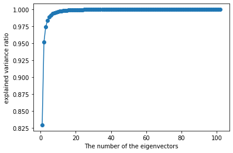

```python
explained_variance_ratio = calculate_explained_variance_ratio(Nas2020week.T)
X = range(1, len(Nas2020week) + 1)
plt.xlabel('The number of the eigenvectors')
plt.ylabel('explained variance ratio') # within-cluster variation
plt.plot(X, explained_variance_ratio, 'o-')
plt.show()
```

According to the explained variance ratio, I think reducing to 3 dimentions is the best.

```python
eigenvectors, points = PCA_model(Nas2020week, newDim=3)
print('eigenvectors:')
print(eigenvectors[:3])
print('reconstruction points:')
print(points)
```

```
102 3
eigenvectors:
[[-0.11502893 -0.11660975 -0.11718338 -0.11688836 -0.11456802 -0.1194187
  -0.12378415 -0.12446909 -0.11195988 -0.11080925 -0.09995385 -0.09371665
  -0.09753386 -0.09823129 -0.10415767 -0.11380556 -0.11472475 -0.116675
  -0.11788527 -0.11941486 -0.12482002 -0.12617709 -0.12848467 -0.13097843
  -0.13193297 -0.13403567 -0.13599212 -0.1462632  -0.14532738 -0.14746711
  -0.14652658 -0.14960797 -0.14983121 -0.15461889 -0.16054733 -0.1627896
  -0.15162968 -0.14700581 -0.14318605 -0.14822034 -0.15029529 -0.15748448
  -0.15367051 -0.15162515 -0.1561797  -0.15974932 -0.16043628 -0.16234305
  -0.16515961 -0.16414513 -0.16530762 -0.16466567 -0.16905446]
 [-0.29246373 -0.29308827 -0.29774905 -0.2868377  -0.25708625 -0.23297765
  -0.22969972 -0.22418347 -0.19589878 -0.18603935 -0.14989647 -0.09757204
  -0.0833951  -0.0870513  -0.09843447 -0.06003408 -0.03155701 -0.05838164
  -0.04406395 -0.02205314 -0.04847588 -0.07715711 -0.06878433 -0.04486189
  -0.00740822  0.02401895  0.0372977   0.07620416  0.04558788  0.05945047
   0.074029    0.10993784  0.07391751  0.11284441  0.10335813  0.10182247
   0.07134646  0.07449427  0.11966886  0.1304767   0.13117278  0.16992243
   0.14923165  0.15594783  0.12945625  0.03061853  0.03989831  0.07258685
   0.07974547  0.07553905  0.11084951  0.12110829  0.10521811]
 [-0.09269822 -0.09926936 -0.11667326 -0.10748775 -0.09195508 -0.06231769
  -0.04831999 -0.06341198 -0.00915876  0.0025186   0.04514081  0.12531328
   0.13001622  0.15455076  0.13641755  0.17725023  0.21011051  0.17457247
   0.15418385  0.15237324  0.10992268  0.072216    0.06689664  0.07786172
   0.08336966  0.1038565   0.10776851  0.14851093  0.12846971  0.12670315
   0.10232651  0.0903454   0.07763576  0.07035673  0.06409422  0.0696669
   0.07400018  0.054562    0.06485323  0.06460654  0.05117532  0.04244729
  -0.02509947 -0.01947266 -0.06167772 -0.12603001 -0.16130981 -0.22595812
  -0.25271077 -0.29551738 -0.303374   -0.31273085 -0.31144818]]
reconstruction points:
[array([ 73.21259008,  74.49914092,  75.23247818,  75.16865536,
        74.19448741,  77.68430325,  80.49812109,  81.62628417,
        72.25817385,  71.47645797,  63.91148447,  59.14529968,
        62.24834814,  61.89761527,  66.19336997,  73.29793788,
        74.07232597,  75.47119587,  77.45537667,  79.41930292,
        83.48154003,  84.45270252,  86.55654802,  88.90728916,
        90.83310747,  92.9141749 ,  94.68733183, 102.25525236,
       101.01891797, 103.10771647, 103.6922059 , 107.57191248,
       106.74251607, 111.80951405, 115.83566916, 117.20656076,
       108.02549612, 105.42700098, 104.12103971, 108.10286086,
```

[output cut: 1215 more lines]

```
       137.80952251, 139.46156644, 140.3286241 , 140.23092724,
       143.67834674]), array([ 46.70421198,  50.50350336,  51.26571066,  56.63107997,
        69.73819135,  91.14628796,  99.90337408, 107.44594139,
        92.90826602,  95.44150598,  91.43207976, 101.70362531,
       118.26413295, 113.25302831, 120.30287897, 159.27905409,
       175.25205816, 166.59262696, 182.02705206, 200.36810117,
       200.02360291, 189.25641801, 200.43825947, 219.97336618,
       246.50026217, 268.8355844 , 281.17552646, 321.76169192,
       302.24966943, 316.26288595, 328.19448265, 360.73623026,
       338.70089073, 375.97051953, 382.41752564, 384.98296103,
       341.14296991, 337.11036217, 358.54235722, 376.04465911,
       382.83167275, 425.03368447, 414.09446348, 413.65954362,
       411.52124789, 361.70744555, 375.04339758, 411.45617295,
       426.26047258, 428.20522956, 455.82780568, 463.01728593,
       460.80828201])]
```

```python
pca = PCA(n_components = 3)
principalComponents = pca.fit_transform(Nas2020week)
principal_df = pd.DataFrame(data = principalComponents, columns=['principal component 1', 'principal component 2', 'principal component 3'])
principal_df
```

|  | principal component 1 | principal component 2 | principal component 3 |
| --- | --- | --- | --- |
| 0 | -1012.319630 | -57.680584 | 9.876001 |
| 1 | 1337.192529 | -46.826923 | -69.491115 |
| 2 | -863.625902 | 48.362764 | -5.567069 |
| 3 | -619.000574 | 155.795744 | 1.026418 |
| 4 | -91.981120 | -14.269280 | 30.822860 |
| ... | ... | ... | ... |
| 97 | -1416.763149 | 56.625274 | -35.350236 |
| 98 | -334.102264 | 23.654625 | 23.932034 |
| 99 | -1240.138515 | 28.432501 | -45.801767 |
| 100 | -965.200048 | -7.456435 | 36.301414 |
| 101 | 286.493044 | -700.691581 | 140.924755 |

102 rows × 3 columns

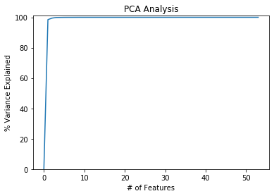

```python
covar_matrix = PCA(n_components = len(Nas2020week.columns))

# calculate variance ratios
covar_matrix.fit(Nas2020week)
variance_ratio = covar_matrix.explained_variance_ratio_

cumulative_sum_of_variance_explained = np.cumsum(np.round(covar_matrix.explained_variance_ratio_, decimals=4) * 100)
cumulative_sum_of_variance_explained = np.insert(cumulative_sum_of_variance_explained, 0, 0)

plt.ylabel('% Variance Explained')
plt.xlabel('# of Features')
plt.title('PCA Analysis')
plt.ylim(0, 101)
plt.plot(cumulative_sum_of_variance_explained)
```

According to the explained variance ratio, I think reducing to 3 dimentions is the best.

# 3. From the NASDAQ csv file, create a Pandas dataframe containing all data of the company AAPL.

```python
NASDAQ_AAPL = pd.read_csv('NASDAQ_100_Data_From_2010.csv', delimiter='\t')
NASDAQ_AAPL = NASDAQ_AAPL[NASDAQ_AAPL['Name'] == 'AAPL']
```

## You wish to use Fourier Transform to study the fluctuations in the daily “close” of AAPL. You should decide on the length of the Fourier Transform (i.e. how may days of data for every batch of Fourier analysis), and decide on how you would overlap the batches (eg. first batch day1 to dayN, second batch dayN/2 to day3N/2, etc).

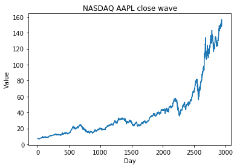

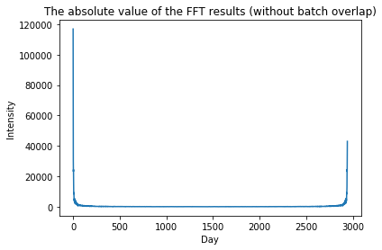

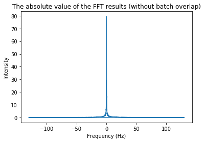

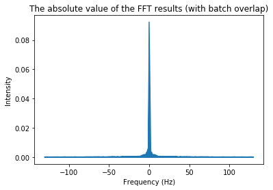

```python
xf = range(len(NASDAQ_AAPL['Close']))
yf = np.array(NASDAQ_AAPL['Close'])
plt.plot(xf, yf)
plt.title('NASDAQ AAPL close wave')
plt.xlabel('Day')
plt.ylabel('Value')
plt.show()

SampleRate  = int(365 / 7 * 5)
dt = 1 / SampleRate
N = len(NASDAQ_AAPL['Close'])

xf = np.arange(len(NASDAQ_AAPL['Close']))
yf = abs(fft(np.array(NASDAQ_AAPL['Close'])))
plt.plot(xf, yf)
plt.title('The absolute value of the FFT results (without batch overlap)')
plt.xlabel('Day')
plt.ylabel('Intensity')
plt.show()

xf = fftfreq(N, dt)
yf = fft(np.array(NASDAQ_AAPL['Close']))
plt.plot(xf, 2 / N * np.abs(yf))
plt.title('The absolute value of the FFT results (without batch overlap)')
plt.xlabel('Frequency (Hz)')
plt.ylabel('Intensity')
plt.show()

yf = []
xf = []
batch_length = 512
window_slide = int(batch_length / 2)
start_id = 0
while start_id < N:
    NASDAQ_AAPL_FFT = fft(np.array(NASDAQ_AAPL['Close'])[start_id : start_id + batch_length])
    # T = N / SampleRate
    # T = np.linspace(0, N / SampleRate, N, endpoint=False)
    yf.extend(NASDAQ_AAPL_FFT / len(NASDAQ_AAPL_FFT))
    start_id += window_slide
    xf.extend(fftfreq(len(NASDAQ_AAPL_FFT), dt))
# xf = fftfreq(N, dt)
plt.plot(xf, 2 / N * np.abs(yf))
plt.title('The absolute value of the FFT results (with batch overlap)')
plt.xlabel('Frequency (Hz)')
plt.ylabel('Intensity')
plt.show()
```

# 4. From the experience gained in Questions 1,2,3 above, and optionally including other techniques, devise a set of useful features to predict the next day “close” price of a company given the previous history. Explain in detail how you would pre-treat the data (eg. normalization, etc). There is no need to implement the machine learning system. The focus should be on feature engineering.

```python
data = pd.read_csv('NASDAQ_100_Data_From_2010.csv', delimiter='\t')
data_close = data.groupby(['Date', 'Name'])['Close'].mean().unstack().fillna(method='bfill').reset_index()
# data_close = data_close[:-428]
# data_close.drop(data_close.index[284], inplace = True)
# data_close.reset_index(inplace=True, drop=True)
Date = data_close['Date']
data_close = data_close.drop('Date', axis=1)
```

```python
# Adding the values and the ratios of the change from the close prices such as (Close_0119 - Close_0118) and (Close_0119 - Close_0118) / Close_0118

N_CHANGE_DAY = 10
# data_close.columns
for col in data_close.columns:
    for n_change_days in range(N_CHANGE_DAY):
        today = np.array(data_close[col])
        yesterday = data_close[col].tolist()
        for day in range(n_change_days):
            yesterday.insert(0, today[0])
            yesterday.pop()
        yesterday = np.array(yesterday)
        data_close[f'{col}_change_{n_change_days}'] = today - yesterday
    today = np.array(data_close[col])
    yesterday = data_close[col].tolist()
    yesterday.insert(0, today[0])
    yesterday.pop()
    yesterday = np.array(yesterday)
    change_ratio = (today - yesterday) / yesterday
    data_close[f'{col}_change%_1'] = change_ratio
    for day in range(2, n_change_days + 1):
        change_ratio = list(change_ratio)
        change_ratio.insert(0, 0)
        change_ratio.pop()
        data_close[f'{col}_change%_{day}'] = change_ratio
data_close.drop([i for i in range(N_CHANGE_DAY)])
data_close
```

| Name | AAPL | ADBE | ADI | ADP | ADSK | AEP | ALGN | AMAT | AMD | AMGN | ... | ZM_change_9 | ZM_change%_1 | ZM_change%_2 | ZM_change%_3 | ZM_change%_4 | ZM_change%_5 | ZM_change%_6 | ZM_change%_7 | ZM_change%_8 | ZM_change%_9 |
| --- | --- | --- | --- | --- | --- | --- | --- | --- | --- | --- | --- | --- | --- | --- | --- | --- | --- | --- | --- | --- | --- |
| 0 | 7.643214 | 37.090000 | 31.670000 | 37.603161 | 25.670000 | 34.939999 | 18.500000 | 14.300000 | 9.700000 | 57.720001 | ... | 0.000000 | 0.000000 | 0.000000 | 0.000000 | 0.000000 | 0.000000 | 0.000000 | 0.000000 | 0.000000 | 0.000000 |
| 1 | 7.656429 | 37.700001 | 31.620001 | 37.401230 | 25.280001 | 34.540001 | 18.010000 | 14.190000 | 9.710000 | 57.220001 | ... | 0.000000 | 0.000000 | 0.000000 | 0.000000 | 0.000000 | 0.000000 | 0.000000 | 0.000000 | 0.000000 | 0.000000 |
| 2 | 7.534643 | 37.619999 | 31.559999 | 37.313435 | 25.340000 | 34.889999 | 17.480000 | 14.160000 | 9.570000 | 56.790001 | ... | 0.000000 | 0.000000 | 0.000000 | 0.000000 | 0.000000 | 0.000000 | 0.000000 | 0.000000 | 0.000000 | 0.000000 |
| 3 | 7.520714 | 36.889999 | 31.309999 | 37.295876 | 25.480000 | 35.189999 | 17.430000 | 14.010000 | 9.470000 | 56.270000 | ... | 0.000000 | 0.000000 | 0.000000 | 0.000000 | 0.000000 | 0.000000 | 0.000000 | 0.000000 | 0.000000 | 0.000000 |
| 4 | 7.570714 | 36.689999 | 31.490000 | 37.243195 | 26.260000 | 35.610001 | 17.660000 | 14.550000 | 9.430000 | 56.770000 | ... | 0.000000 | 0.000000 | 0.000000 | 0.000000 | 0.000000 | 0.000000 | 0.000000 | 0.000000 | 0.000000 | 0.000000 |
| ... | ... | ... | ... | ... | ... | ... | ... | ... | ... | ... | ... | ... | ... | ... | ... | ... | ... | ... | ... | ... | ... |
| 2938 | 154.300003 | 666.590027 | 162.440002 | 207.380005 | 288.750000 | 90.410004 | 721.500000 | 135.830002 | 109.919998 | 226.369995 | ... | -43.009979 | 0.010844 | 0.014543 | 0.004698 | -0.166906 | 0.019630 | 0.000528 | 0.008557 | -0.007377 | -0.003076 |
| 2939 | 156.690002 | 661.390015 | 163.270004 | 202.229996 | 287.459991 | 88.910004 | 716.210022 | 136.490005 | 109.150002 | 221.339996 | ... | -40.290009 | 0.005599 | 0.010844 | 0.014543 | 0.004698 | -0.166906 | 0.019630 | 0.000528 | 0.008557 | -0.007377 |
| 2940 | 155.110001 | 663.219971 | 163.669998 | 205.130005 | 289.559998 | 90.680000 | 729.919983 | 133.559998 | 106.169998 | 220.869995 | ... | -44.139984 | -0.021203 | 0.005599 | 0.010844 | 0.014543 | 0.004698 | -0.166906 | 0.019630 | 0.000528 | 0.008557 |
| 2941 | 154.070007 | 661.679993 | 168.809998 | 203.160004 | 287.679993 | 90.400002 | 726.409973 | 135.000000 | 106.150002 | 215.580002 | ... | -44.770020 | 0.007697 | -0.021203 | 0.005599 | 0.010844 | 0.014543 | 0.004698 | -0.166906 | 0.019630 | 0.000528 |
| 2942 | 148.970001 | 658.940002 | 169.940002 | 200.830002 | 284.429993 | 88.830002 | 720.669983 | 136.839996 | 105.199997 | 213.750000 | ... | -39.309998 | 0.019063 | 0.007697 | -0.021203 | 0.005599 | 0.010844 | 0.014543 | 0.004698 | -0.166906 | 0.019630 |

2943 rows × 2040 columns

Adding the values and the ratios of the change from the close prices such as (Close_0119 - Close_0118) and (Close_0119 - Close_0118) / Close_0118

```python
data_close.describe()
```

| Name | AAPL | ADBE | ADI | ADP | ADSK | AEP | ALGN | AMAT | AMD | AMGN | ... | ZM_change_9 | ZM_change%_1 | ZM_change%_2 | ZM_change%_3 | ZM_change%_4 | ZM_change%_5 | ZM_change%_6 | ZM_change%_7 | ZM_change%_8 | ZM_change%_9 |
| --- | --- | --- | --- | --- | --- | --- | --- | --- | --- | --- | --- | --- | --- | --- | --- | --- | --- | --- | --- | --- | --- |
| count | 2943.000000 | 2943.000000 | 2943.000000 | 2943.000000 | 2943.000000 | 2943.000000 | 2943.000000 | 2943.000000 | 2943.000000 | 2943.000000 | ... | 2943.000000 | 2943.000000 | 2943.000000 | 2943.000000 | 2943.000000 | 2943.000000 | 2943.000000 | 2943.000000 | 2943.000000 | 2943.000000 |
| mean | 39.723350 | 156.510537 | 71.413904 | 95.823264 | 96.693272 | 60.347088 | 147.938206 | 34.543428 | 18.946925 | 144.526674 | ... | 0.731961 | 0.000733 | 0.000727 | 0.000724 | 0.000731 | 0.000729 | 0.000726 | 0.000721 | 0.000719 | 0.000776 |
| std | 33.713824 | 152.523980 | 35.852825 | 47.052177 | 77.279385 | 18.549134 | 159.941812 | 28.862957 | 25.450262 | 60.703000 | ... | 14.455134 | 0.020103 | 0.020100 | 0.020099 | 0.020095 | 0.020095 | 0.020094 | 0.020093 | 0.020093 | 0.019853 |
| min | 6.858929 | 22.690001 | 26.500000 | 33.898155 | 22.950001 | 30.969999 | 13.270000 | 9.850000 | 1.620000 | 48.270000 | ... | -140.000000 | -0.173702 | -0.173702 | -0.173702 | -0.173702 | -0.173702 | -0.173702 | -0.173702 | -0.173702 | -0.173702 |
| 25% | 18.197321 | 36.500000 | 41.450001 | 51.369621 | 38.905001 | 43.369999 | 32.439999 | 14.305000 | 3.850000 | 86.419998 | ... | 0.000000 | 0.000000 | 0.000000 | 0.000000 | 0.000000 | 0.000000 | 0.000000 | 0.000000 | 0.000000 | 0.000000 |
| 50% | 27.932501 | 85.500000 | 58.500000 | 86.029999 | 58.189999 | 58.660000 | 63.320000 | 22.459999 | 7.790000 | 156.369995 | ... | 0.000000 | 0.000000 | 0.000000 | 0.000000 | 0.000000 | 0.000000 | 0.000000 | 0.000000 | 0.000000 | 0.000000 |
| 75% | 46.641251 | 250.435005 | 94.535000 | 136.375000 | 136.730003 | 74.325001 | 243.564995 | 46.750000 | 20.005000 | 186.775002 | ... | 0.000000 | 0.000000 | 0.000000 | 0.000000 | 0.000000 | 0.000000 | 0.000000 | 0.000000 | 0.000000 | 0.000000 |
| max | 156.690002 | 666.590027 | 172.580002 | 216.720001 | 342.269989 | 104.330002 | 729.919983 | 143.050003 | 118.769997 | 260.950012 | ... | 184.179993 | 0.407844 | 0.407844 | 0.407844 | 0.407844 | 0.407844 | 0.407844 | 0.407844 | 0.407844 | 0.407844 |

8 rows × 2040 columns

```python
# StandardScaler = (value - mean) / std
data_close_std = StandardScaler().fit_transform(data_close)
data_close_std = pd.DataFrame(data_close_std, columns=data_close.columns )
data_close_std['mean'] = data_close_std.mean(axis='columns')
# data_close_std['Date'] = Date
data_close_std
```

| Name | AAPL | ADBE | ADI | ADP | ADSK | AEP | ALGN | AMAT | AMD | AMGN | ... | ZM_change%_1 | ZM_change%_2 | ZM_change%_3 | ZM_change%_4 | ZM_change%_5 | ZM_change%_6 | ZM_change%_7 | ZM_change%_8 | ZM_change%_9 | mean |
| --- | --- | --- | --- | --- | --- | --- | --- | --- | --- | --- | --- | --- | --- | --- | --- | --- | --- | --- | --- | --- | --- |
| 0 | -0.951704 | -0.783095 | -1.108718 | -1.237562 | -0.919202 | -1.369951 | -0.809421 | -0.701483 | -0.363395 | -1.430266 | ... | -0.036474 | -0.036157 | -0.036027 | -0.036393 | -0.036299 | -0.036117 | -0.035874 | -0.035795 | -0.039083 | -0.100857 |
| 1 | -0.951312 | -0.779095 | -1.110112 | -1.241855 | -0.924249 | -1.391519 | -0.812485 | -0.705295 | -0.363002 | -1.438504 | ... | -0.036474 | -0.036157 | -0.036027 | -0.036393 | -0.036299 | -0.036117 | -0.035874 | -0.035795 | -0.039083 | -0.078338 |
| 2 | -0.954925 | -0.779620 | -1.111786 | -1.243721 | -0.923473 | -1.372647 | -0.815799 | -0.706334 | -0.368504 | -1.445589 | ... | -0.036474 | -0.036157 | -0.036027 | -0.036393 | -0.036299 | -0.036117 | -0.035874 | -0.035795 | -0.039083 | -0.074286 |
| 3 | -0.955338 | -0.784407 | -1.118760 | -1.244094 | -0.921661 | -1.356471 | -0.816112 | -0.711532 | -0.372434 | -1.454157 | ... | -0.036474 | -0.036157 | -0.036027 | -0.036393 | -0.036299 | -0.036117 | -0.035874 | -0.035795 | -0.039083 | -0.091621 |
| 4 | -0.953855 | -0.785718 | -1.113739 | -1.245214 | -0.911566 | -1.333825 | -0.814673 | -0.692820 | -0.374006 | -1.445918 | ... | -0.036474 | -0.036157 | -0.036027 | -0.036393 | -0.036299 | -0.036117 | -0.035874 | -0.035795 | -0.039083 | -0.072139 |
| ... | ... | ... | ... | ... | ... | ... | ... | ... | ... | ... | ... | ... | ... | ... | ... | ... | ... | ... | ... | ... | ... |
| 2938 | 3.399084 | 3.344826 | 2.539314 | 2.371318 | 2.485648 | 1.620993 | 3.586675 | 3.509820 | 3.575151 | 1.348487 | ... | 0.503057 | 0.687509 | 0.197735 | -8.343511 | 0.940703 | -0.009816 | 0.390070 | -0.403005 | -0.194067 | 0.309350 |
| 2939 | 3.469987 | 3.310727 | 2.562468 | 2.261847 | 2.468953 | 1.540113 | 3.553595 | 3.532691 | 3.544891 | 1.265611 | ... | 0.242069 | 0.503451 | 0.687653 | 0.197417 | -8.343498 | 0.940927 | -0.009571 | 0.390152 | -0.410717 | 0.078663 |
| 2940 | 3.423114 | 3.322727 | 2.573626 | 2.323491 | 2.496131 | 1.635552 | 3.639328 | 3.431159 | 3.427780 | 1.257867 | ... | -1.091376 | 0.242426 | 0.503591 | 0.687434 | 0.197513 | -8.343672 | 0.941248 | -0.009491 | 0.391995 | 0.019518 |
| 2941 | 3.392261 | 3.312629 | 2.717014 | 2.281616 | 2.471800 | 1.620454 | 3.617378 | 3.481059 | 3.426994 | 1.170707 | ... | 0.346499 | -1.091208 | 0.242561 | 0.503334 | 0.687535 | 0.197705 | -8.344095 | 0.941334 | -0.012463 | -0.006390 |
| 2942 | 3.240962 | 3.294661 | 2.748538 | 2.232088 | 2.429738 | 1.535800 | 3.581484 | 3.544819 | 3.389660 | 1.140555 | ... | 0.911974 | 0.346870 | -1.091100 | 0.242251 | 0.503434 | 0.687748 | 0.197967 | -8.344070 | 0.949817 | -0.124584 |

2943 rows × 2041 columns

Using StandardScaler = (value - mean) / std since the ranges of the values is different. Thus, I use the standard normalization.

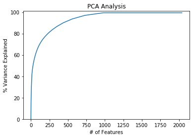

```python
covar_matrix = PCA(n_components = len(data_close_std.columns))

# calculate variance ratios
covar_matrix.fit(data_close_std)
variance_ratio = covar_matrix.explained_variance_ratio_

cumulative_sum_of_variance_explained = np.cumsum(np.round(covar_matrix.explained_variance_ratio_, decimals=4) * 100)
cumulative_sum_of_variance_explained = np.insert(cumulative_sum_of_variance_explained, 0, 0)

plt.ylabel('% Variance Explained')
plt.xlabel('# of Features')
plt.title('PCA Analysis')
plt.ylim(0, 101)
plt.plot(cumulative_sum_of_variance_explained)
```

```python
k = 0
for i in range(len(data_close_std.columns)):
    if cumulative_sum_of_variance_explained[i] > 90:
        k = i
        break

# eigenvectors, points = PCA_model(data_close_std, newDim=k)
pca = PCA(n_components = k)
principalComponents = pca.fit_transform(data_close_std)
columns = [f'principal component {i}' for i in range(k)]
principal_df = pd.DataFrame(data = principalComponents, columns=columns)
principal_df['Date'] = Date
principal_df
```

|  | principal component 0 | principal component 1 | principal component 2 | principal component 3 | principal component 4 | principal component 5 | principal component 6 | principal component 7 | principal component 8 | principal component 9 | ... | principal component 427 | principal component 428 | principal component 429 | principal component 430 | principal component 431 | principal component 432 | principal component 433 | principal component 434 | principal component 435 | Date |
| --- | --- | --- | --- | --- | --- | --- | --- | --- | --- | --- | --- | --- | --- | --- | --- | --- | --- | --- | --- | --- | --- |
| 0 | 3.897708 | -8.661121 | -2.490997 | 1.020827 | 1.725275 | 2.089840 | -0.157726 | -0.119610 | 0.127842 | -0.073658 | ... | 0.018824 | 0.060253 | 0.063580 | 0.020272 | 0.084308 | -0.020722 | 0.001823 | -0.079300 | 0.121562 | 2010-01-04 |
| 1 | 2.810745 | -9.534767 | -1.832081 | 0.710188 | 1.318784 | 1.390425 | -0.878205 | 0.050502 | 0.102680 | 0.184173 | ... | -0.324444 | -0.198241 | 0.224210 | 0.514153 | 0.201327 | 0.149226 | 0.019831 | -0.261503 | 0.225863 | 2010-01-05 |
| 2 | 3.009492 | -9.337997 | -3.036811 | 1.414549 | 0.676225 | 0.936757 | -0.122783 | -0.945912 | -0.066727 | -0.199338 | ... | -0.195930 | 0.761587 | -0.599173 | 0.008521 | -0.348074 | -0.629409 | -0.489344 | 0.336312 | 0.322715 | 2010-01-06 |
| 3 | 3.866255 | -8.900569 | -3.770673 | 0.189030 | 1.334395 | 0.625018 | 1.128129 | -0.570978 | 1.004498 | -0.771345 | ... | 0.375453 | -0.148495 | -0.616502 | 0.022987 | -0.131713 | 0.526780 | -0.059313 | -0.367793 | -0.563557 | 2010-01-07 |
| 4 | 2.502672 | -9.724956 | -1.988608 | -0.327807 | 0.723264 | 1.519926 | -0.494769 | 1.837712 | 0.281612 | -0.094990 | ... | 0.099261 | 0.324434 | -0.204986 | -0.092429 | 0.081507 | 0.297989 | -0.123080 | -0.306980 | 0.251103 | 2010-01-08 |
| ... | ... | ... | ... | ... | ... | ... | ... | ... | ... | ... | ... | ... | ... | ... | ... | ... | ... | ... | ... | ... | ... |
| 2938 | -14.645865 | 28.846581 | 7.169922 | -0.015208 | 0.038674 | 5.759118 | 0.321882 | -3.648626 | 0.590722 | 4.471336 | ... | -0.289304 | -0.025953 | -2.114989 | 1.481909 | 0.526067 | 0.178510 | 0.641188 | -0.844883 | 0.188802 | 2021-09-03 |
| 2939 | -1.504168 | 33.695231 | 3.142621 | 3.896117 | 6.143726 | 6.107012 | -0.215005 | 0.139596 | 3.180655 | -0.179851 | ... | 0.684603 | 0.297251 | -1.447474 | -0.547864 | -0.610004 | 0.002857 | 0.366971 | 1.403115 | 0.600860 | 2021-09-07 |
| 2940 | 1.457729 | 27.172636 | 8.839507 | -8.683640 | -2.350985 | 0.238541 | -0.126227 | 1.295856 | -1.790216 | -5.932125 | ... | 0.069731 | -1.437536 | -0.127835 | -1.213967 | -0.577527 | -0.515930 | 1.326438 | -0.053518 | 0.100878 | 2021-09-08 |
| 2941 | 5.352650 | 29.759547 | 7.020854 | 0.140367 | -3.565496 | -0.524958 | -3.377625 | -2.121009 | -0.020994 | 1.245830 | ... | -0.307631 | -0.541919 | 0.745761 | 0.332410 | 0.006270 | -0.321665 | -0.976444 | 0.199759 | 0.069679 | 2021-09-09 |
| 2942 | 11.159111 | 27.816589 | 11.301931 | -0.041094 | 0.859093 | -0.981409 | -0.265617 | -2.412148 | 2.252277 | 3.619168 | ... | 0.434341 | 0.238285 | 2.059561 | 1.106390 | -0.967789 | -0.870901 | -0.167677 | -0.395589 | -0.272313 | 2021-09-10 |

2943 rows × 437 columns

Using principal components which can explain up to 90%.